# DATS6101 Group Project: Predicting Heart Attacks - EDA Code

Jonathan Giguere, Jesse Borg, Ese Emuraye, Sarah Gates

December 11th 2019

## Introduction

For project two, our group used the Behavior Risk Factor Surveillance System (BRFSS) data from the 2013 survey. This data is collected by the CDC from all 50 states via landline phone and cellular phone covering a variety of health related topics. Generalizability is limited to those in the population with access to a landline or cell phone as well as to those living in a private residence or college housing. These factors leave out individuals and households who fall outside of these conditions, which means that random sampling is not fully taking place. Sampling bias occurs in the form of non-response, indicated by the NA/null points that exist in the dataset.

Our goal is to analyze factors that we believe may be related to heart attacks. We will not assume causality in the EDA portion of our project. We will spend time in it exploring relationships between these variables. After this, we will build and analyze the effectiveness of building two models as they relate to classifying and possibly predicting the occurence of a heart attack in an individual. We will utilize the decision tree method for classification and logistic regression for prediction. We selected these methods because our data includes both categorica and numeric variables and needed flexible methods to be able to work with both types.

This file contains the full code we developed for the project and will be used to then write up the summary report.

### Loading the Data

Start by loading the packages we know will be needed for the project. Then load the brfss 2013 data which is as an RData file as opposed to a csv.

## Cleaning the data

We started by choosing the variables which we think will be useful or the most interesting for this study and then renamed them to have more logical or descriptive names.

Once this was done, check to see how many missing values for each column.

```
##                state               weight                month
##                    0                    0                    3
##                  sex              veteran             diabetes
##                    7                  746                  832
##              high_bp               stroke               asthma
##                 1420                 1467                 1559
##       kidney_disease      health_coverage           gen_health
##                 1721                 1904                 1985
##      education_level           depression         heart_attack
##                 2274                 2289                 2587
##    employment_status       marital_status               angina
##                 3386                 3420                 4423
##        age5yr_bucket           sleep_time        mental_health
##                 4730                 7387                 8627
##      difficulty_walk      smokeless_tabac            smoke_100
##                12764                14018                14920
##          alc_past_30           fruit_freq          exercise_30
##                19644                33798                34029
##       green_veg_freq               income       told_high_chol
##                35157                71426                71662
## time_since_cholcheck       dr_visits_year          prediabetes
##                73178               154152               257913
##            binge_alc        alc_perday_30           freq_smoke
##               260444               260590               276983
##              bp_meds        aspirin_daily            soda_freq
##               293201               355557               388580
##             pregnant      stop_smoke_year       has_asthma_now
##               414790               415421               426435
##      work_hours_week         depressed_30           anxious_30
##               459413               491284               491288
```

Since there are some columns with a lot of missing values, we decided to drop the ones with more than 100,000 missing entries.

We then removed the rows which have any missing values so that the data we have is complete.

Inspect the dataframe after the missing values have been removed, which shows that there are still over 300,000 observations and 31 variables. This is more than enough data for what we need.

```
## 'data.frame':    313247 obs. of  31 variables:
##  $ state               : Factor w/ 55 levels "0","Alabama",..: 2 2 2 2 2 2 2 2 2 2 ...
##  $ month               : Factor w/ 12 levels "January","February",..: 1 1 1 2 3 3 4 4 4 6 ...
##  $ gen_health          : Factor w/ 5 levels "Excellent","Very good",..: 3 3 2 3 2 3 1 3 4 4 ...
##  $ mental_health       : int  0 2 0 2 0 0 0 0 0 1 ...
##  $ health_coverage     : Factor w/ 2 levels "Yes","No": 1 1 1 1 1 1 1 1 2 1 ...
##  $ sleep_time          : int  6 9 8 6 8 6 8 8 3 8 ...
##  $ high_bp             : Factor w/ 4 levels "Yes","Yes, but female told only during pregnancy",..: 3 3 3 1 1 1 3 3 1 1 ...
##  $ time_since_cholcheck: Factor w/ 4 levels "Within past year",..: 1 4 1 2 1 1 1 1 1 1 ...
##  $ told_high_chol      : Factor w/ 2 levels "Yes","No": 2 2 1 2 1 1 1 2 1 1 ...
##  $ heart_attack        : Factor w/ 2 levels "Yes","No": 2 2 2 2 2 2 2 2 1 2 ...
##  $ angina              : Factor w/ 2 levels "Yes","No": 2 2 2 2 2 1 2 2 2 2 ...
##  $ stroke              : Factor w/ 2 levels "Yes","No": 2 2 2 2 2 2 2 2 2 2 ...
##  $ asthma              : Factor w/ 2 levels "Yes","No": 2 2 2 1 2 2 2 2 1 1 ...
##  $ depression          : Factor w/ 2 levels "Yes","No": 1 1 2 2 2 2 2 2 1 1 ...
```

[output cut: 19 more lines]

For the factors, we want to change some of the variable factors to be more intuitive/descriptive, start by inspecting the levels for the factors we might want to change.

```
## [1] "Yes"
## [2] "Yes, but female told only during pregnancy"
## [3] "No"
## [4] "Told borderline or pre-hypertensive"
```

```
## [1] "Employed for wages"               "Self-employed"
## [3] "Out of work for 1 year or more"   "Out of work for less than 1 year"
## [5] "A homemaker"                      "A student"
## [7] "Retired"                          "Unable to work"
```

```
## [1] "Every day"  "Some days"  "Not at all"
```

```
## [1] "Yes"
## [2] "Yes, but female told only during pregnancy"
## [3] "No"
## [4] "No, pre-diabetes or borderline diabetes"
```

Change the yes/no factors to 1/0 for model purposes and change other factors in the variables above to make them better grouped.

Inspect the structure of the dataframe with changed variables

```
## 'data.frame':    313247 obs. of  31 variables:
##  $ state               : Factor w/ 55 levels "0","Alabama",..: 2 2 2 2 2 2 2 2 2 2 ...
##  $ month               : Factor w/ 12 levels "January","February",..: 1 1 1 2 3 3 4 4 4 6 ...
##  $ gen_health          : Factor w/ 5 levels "Excellent","Very good",..: 3 3 2 3 2 3 1 3 4 4 ...
##  $ mental_health       : int  0 2 0 2 0 0 0 0 0 1 ...
##  $ health_coverage     : Factor w/ 2 levels "1","0": 1 1 1 1 1 1 1 1 2 1 ...
##  $ sleep_time          : int  6 9 8 6 8 6 8 8 3 8 ...
##  $ high_bp             : Factor w/ 2 levels "1","0": 2 2 2 1 1 1 2 2 1 1 ...
##  $ time_since_cholcheck: Factor w/ 4 levels "Within past year",..: 1 4 1 2 1 1 1 1 1 1 ...
##  $ told_high_chol      : Factor w/ 2 levels "Yes","No": 2 2 1 2 1 1 1 2 1 1 ...
##  $ heart_attack        : Factor w/ 2 levels "1","0": 2 2 2 2 2 2 2 2 1 2 ...
##  $ angina              : Factor w/ 2 levels "1","0": 2 2 2 2 2 1 2 2 2 2 ...
##  $ stroke              : Factor w/ 2 levels "1","0": 2 2 2 2 2 2 2 2 2 2 ...
##  $ asthma              : Factor w/ 2 levels "1","0": 2 2 2 1 2 2 2 2 1 1 ...
##  $ depression          : Factor w/ 2 levels "1","0": 1 1 2 2 2 2 2 2 1 1 ...
```

[output cut: 19 more lines]

## Exploratory Data Analysis

This part will be the EDA of our analysis, which will help visualize the data better and help draw some early conclusions. This will serve as a good base for when the model analysis is carried out.

Start by looking at the general number of heart attacks in the US and how this changes by state. First the data must be cleaned before it is plotted as a heat map.

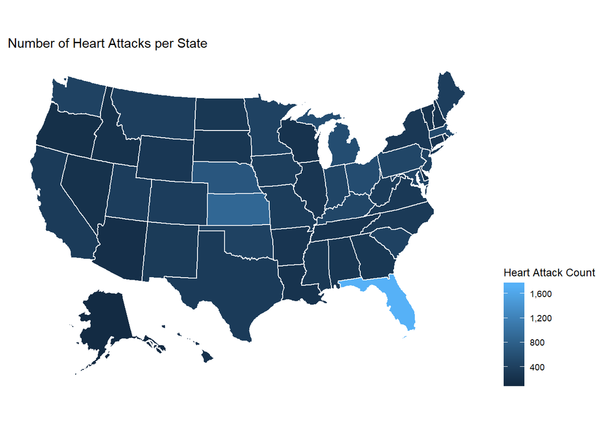

We also want to look at the number of participants by US state.

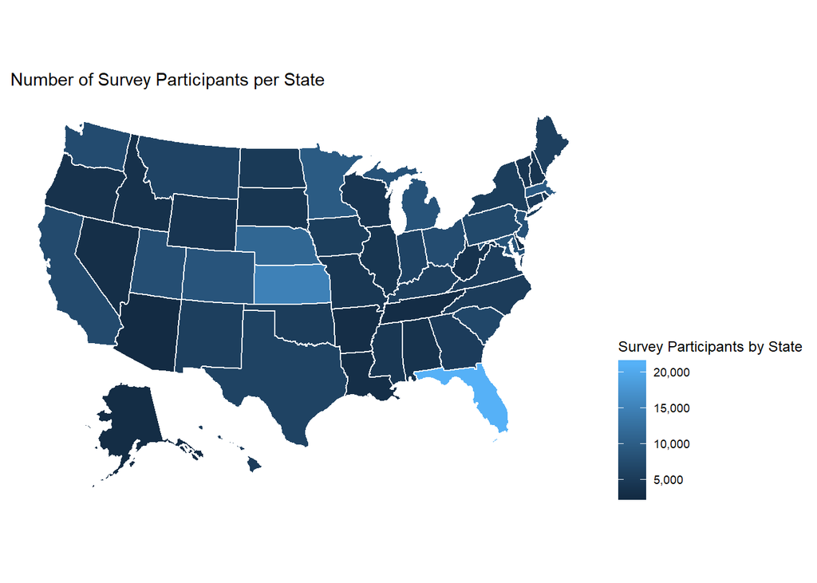

Look at how the porportion of heart attacks vary depending on the general health of the participants.

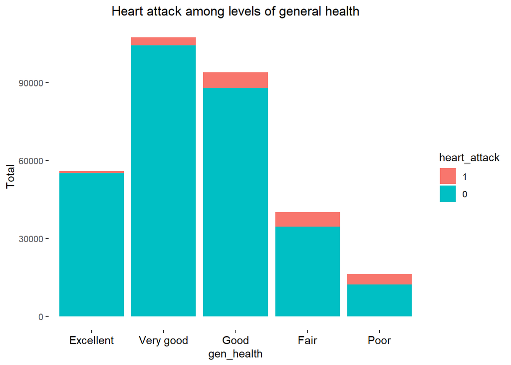

Look at how the porportion of heart attacks vary depending on whether the participants have health insurance or not.

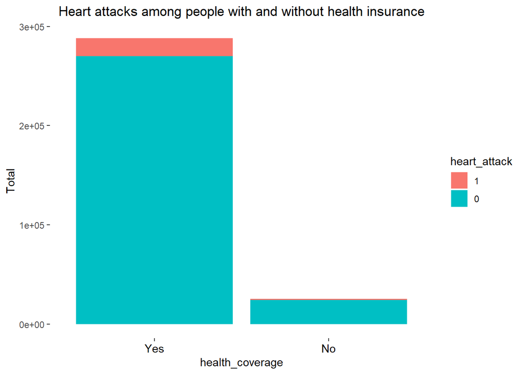

Look at how the porportion of heart attacks vary depending on whether the participants have high blood pressure or not.

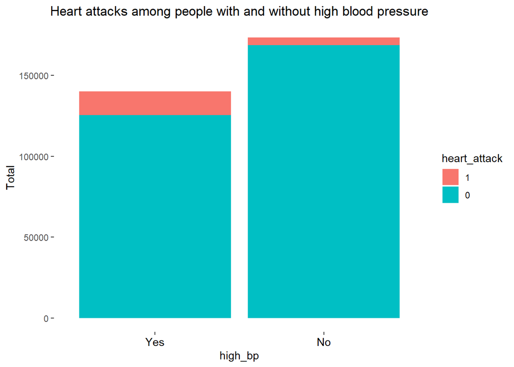

To make the visualisation more accurate, the anomalus values for sleep will be removed as it will skew the results and not give true results.

Look at how the porportion of heart attacks vary depending on how many hours the participants sleep on average.

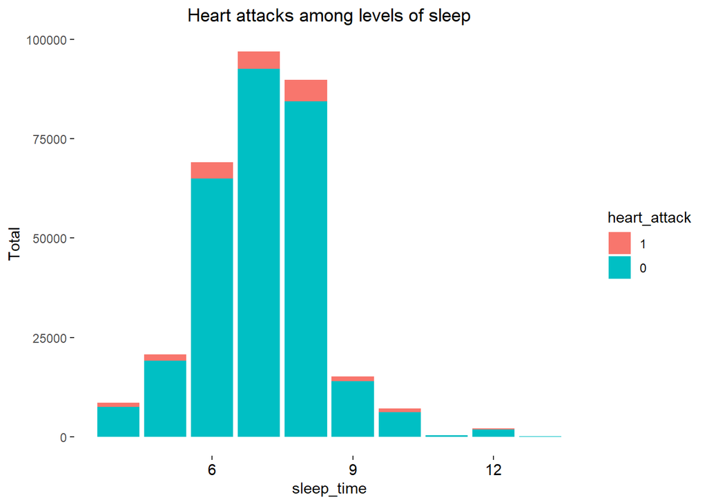

In exploring cholesterol and time since cholesterol check, we wanted to see if there was a pattern across age for ignoring unpleasant information. The two variables to extrapolate are if someone was told they have high colesterol and the last time they had their cholesterol check. Basically, we wanted to see if once a person is exposed to the negative information of being told they have high cholesterol, is there a pattern in their likeliness to check their cholesterol level morefrequently across age brackets?

First, classify Recent and Not Recent under last cholesterol check as whether the check occurred in the last year or not. Then create a subset of only individuals told that they have high cholesterol.

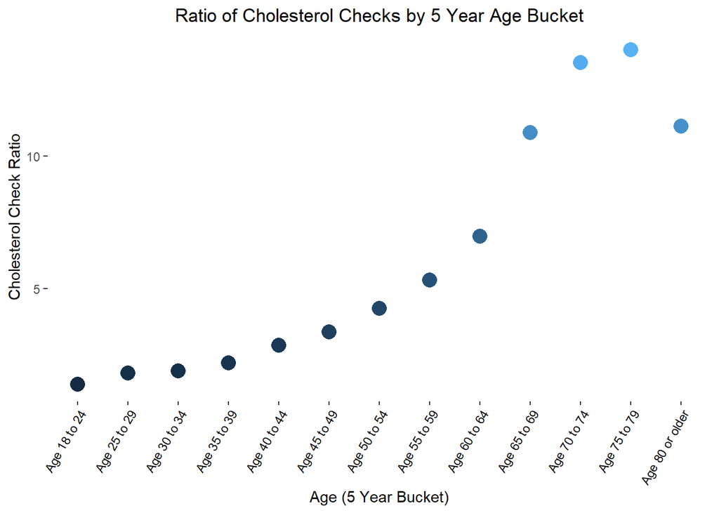

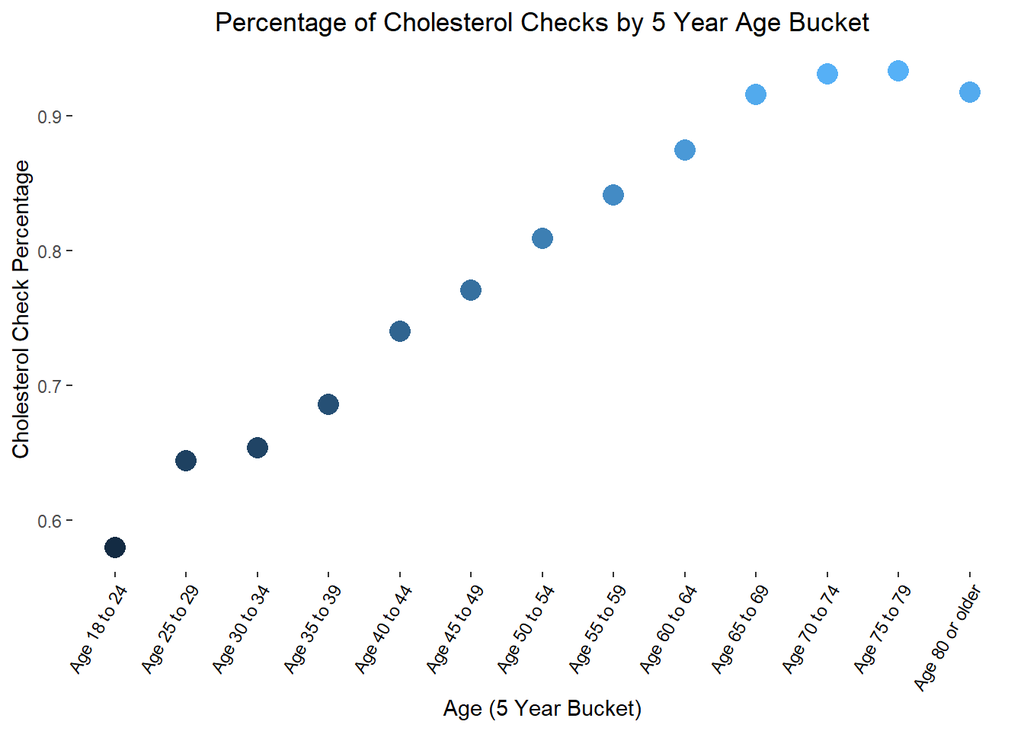

```
## # A tibble: 13 x 4
##    age5yr_bucket   cholchkratio cholchkpercent cholchkcount
##    <fct>                  <dbl>          <dbl>        <int>
##  1 Age 18 to 24            1.38          0.579          673
##  2 Age 25 to 29            1.81          0.644         1303
##  3 Age 30 to 34            1.89          0.654         2611
##  4 Age 35 to 39            2.19          0.686         4052
##  5 Age 40 to 44            2.85          0.740         6154
##  6 Age 45 to 49            3.36          0.771         9061
##  7 Age 50 to 54            4.24          0.809        14224
##  8 Age 55 to 59            5.31          0.842        18385
##  9 Age 60 to 64            6.98          0.875        20918
## 10 Age 65 to 69           10.9           0.916        20385
## 11 Age 70 to 74           13.5           0.931        15452
## 12 Age 75 to 79           14.0           0.933        10849
## 13 Age 80 or older        11.1           0.918        11393
```

Look at how the ratio of heart attacks vary with the participants by their age and the time since their last cholesterol check.

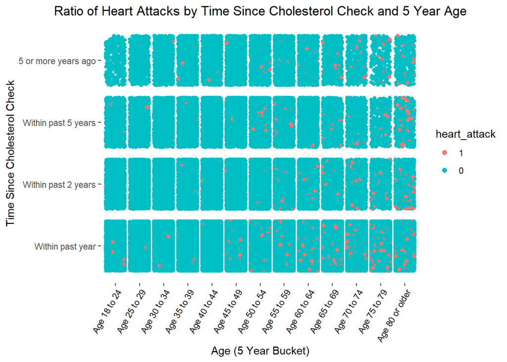

Look at the ratio of heart attacks depending on whether the participants have smoked 100 cigarettes

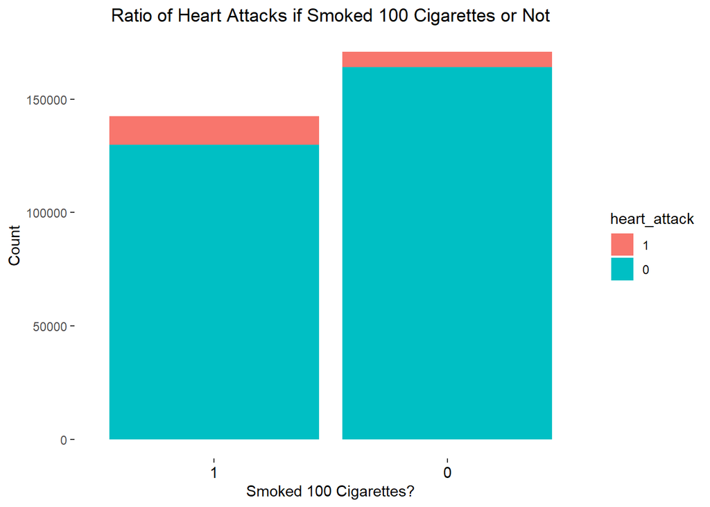

Look at the ratio of heart attacks depending on whether the participants have had an angina or not.

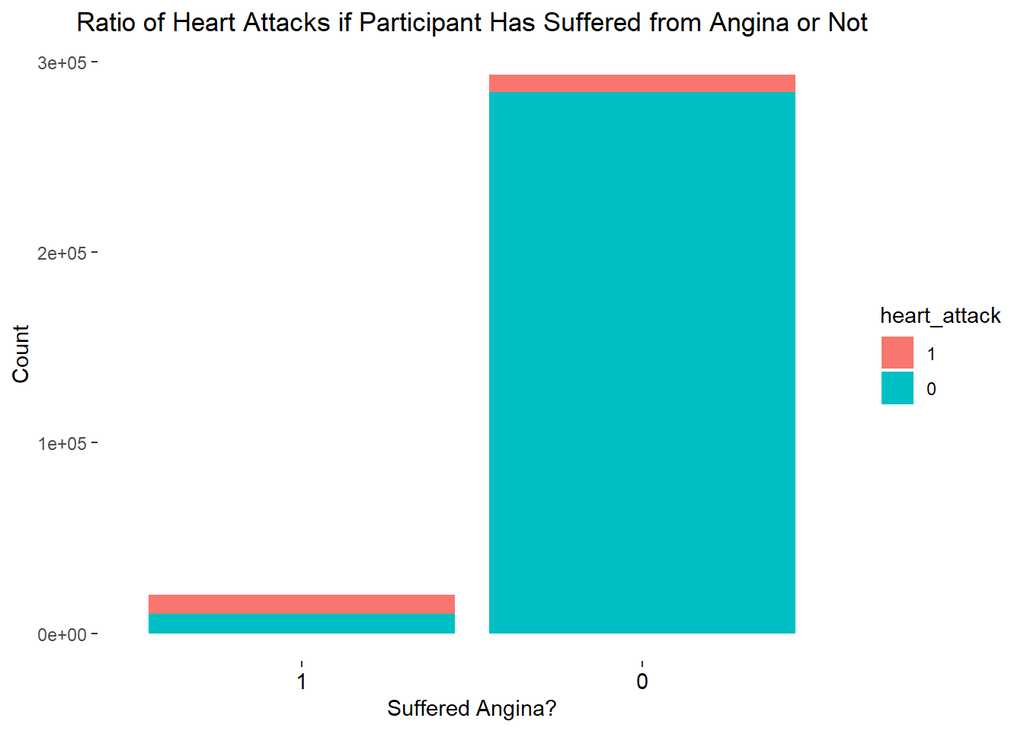

Look at the ratio of heart attacks depending on whether the participants have suffered from depression or not.

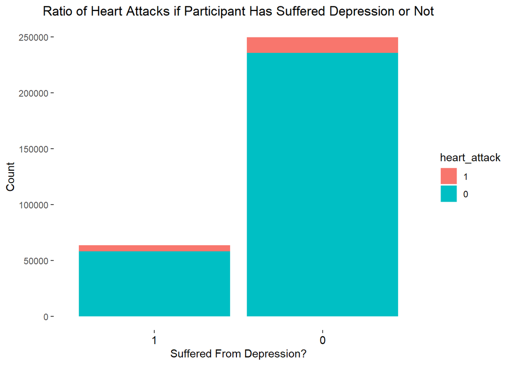

Look at the ratio of heart attacks depending on whether the participants have suffered from kidney disease or not.

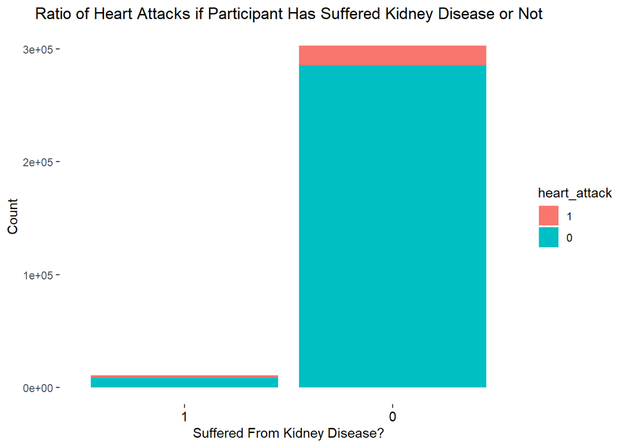

We also want to look at whether smoking or using smokeless tobacco has any affect on the rate of heart attacks and see the ratio of participants which smoke or use such smokless tobacco products like chewing tobacco. We also want to look at the effect of alcohol on heart attacks, how fruit and vegetable consumption affect the rate of heart attack and the frequency of exercise. First EDAs will be carried out to see what proprtion of the participants do these different factors and how many of them suffered a heart attack or not.

Look at the ratio of heart attacks depending on whether participants have smoked 100 cigarettes or not.

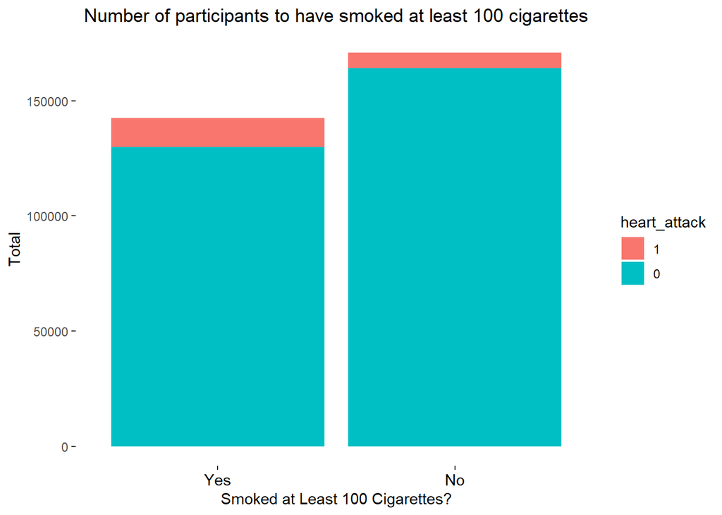

Look at the ratio of heart attacks depending on whether participants have used smokeless tobacco products or not.

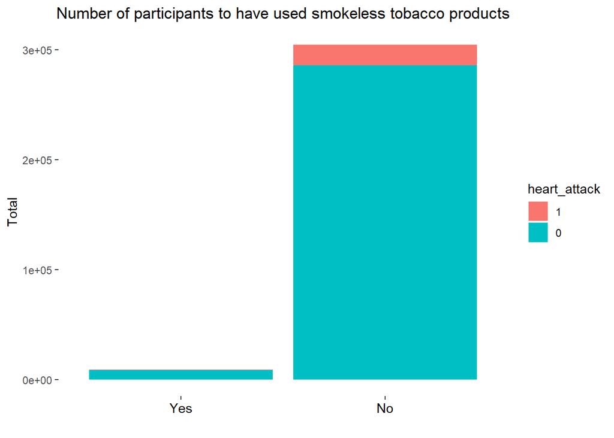

Look at the frequency of alcohol consumption among participants, by number of drinks had in 2013

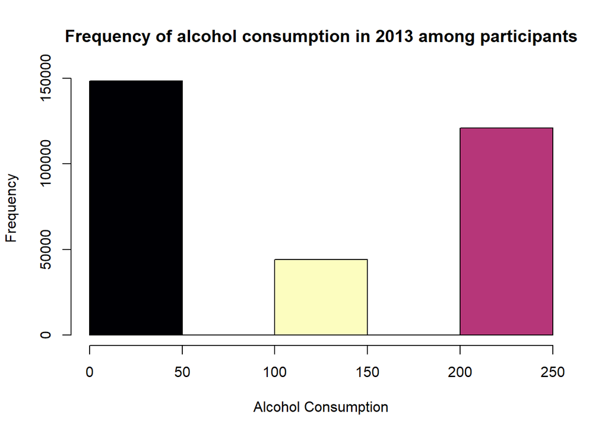

Look at the frequency of fruit consumption among participants, by number of days fruit was consumed in 2013

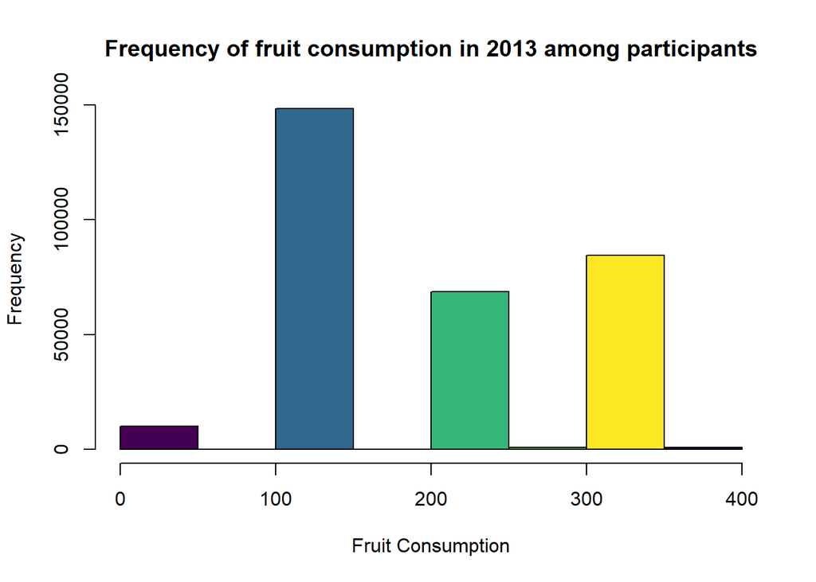

Look at the frequency of green vegetable consumption among participants, by number of days green vegetables were consumed in 2013

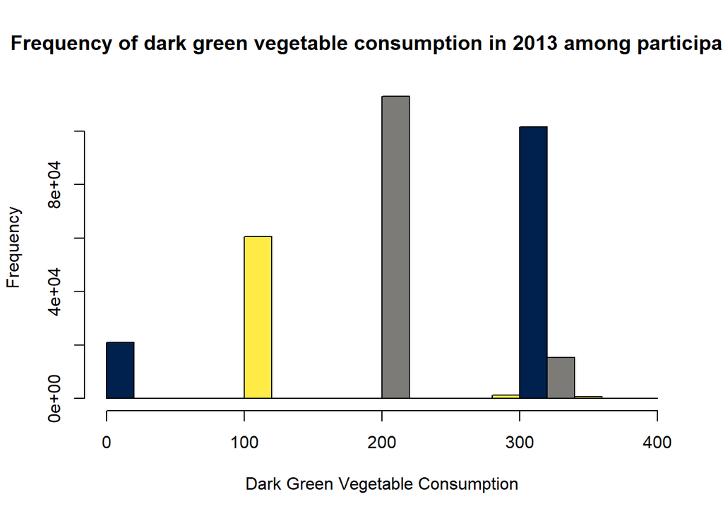

Look at the number of participants to have exercised within the past 30 days by 5 year age bucket.

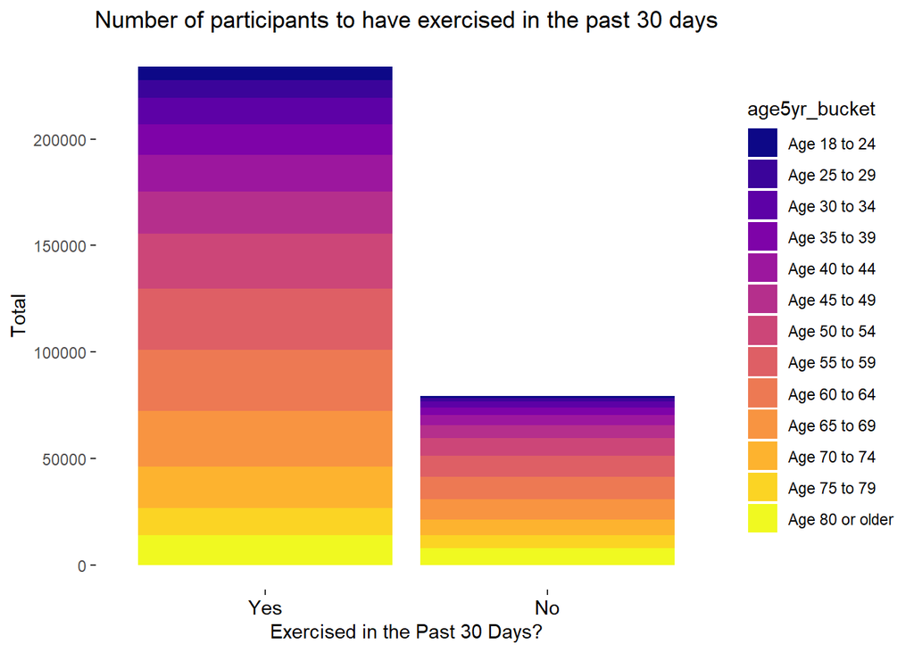

Finally for the EDA, look at how diabetes, employment status, income, weight and sex affects heart attack. To do this we will see which ratio of participants have diabetes and which ratio have had heart attacks. We will also look at how employment, income and weight differs with the amount of participants who have suffered heart attacks. Finally we will see if male or female participants suffer more from heart attacks.

Look at the ratio of heart attacks depending on whether or not participants suffer from diabetes.

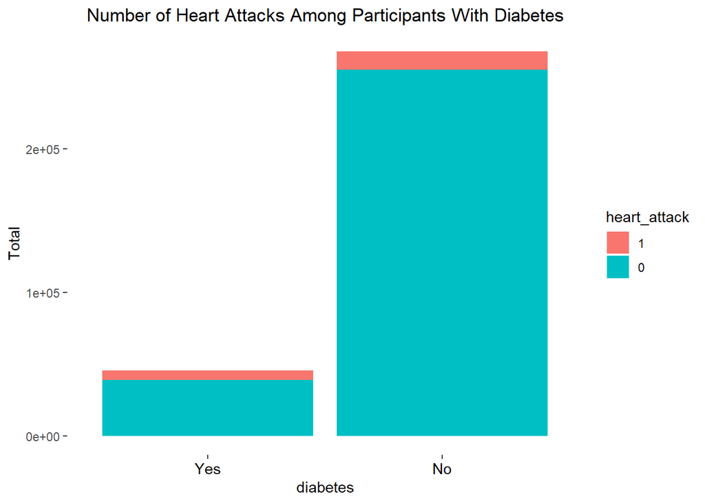

Look at the ratio of heart attacks depending on the participants’ employment status.

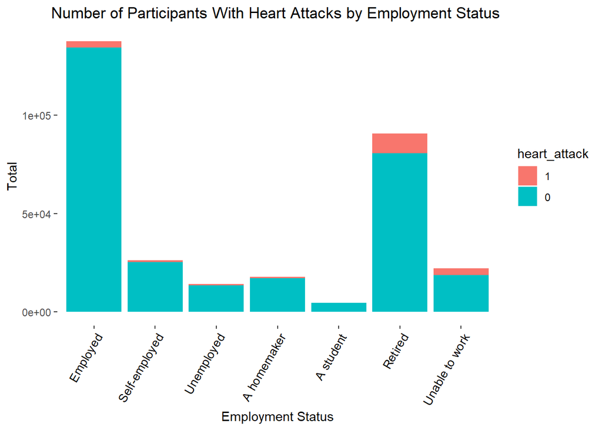

Look at the ratio of heart attacks depending on the participants’ annual income.

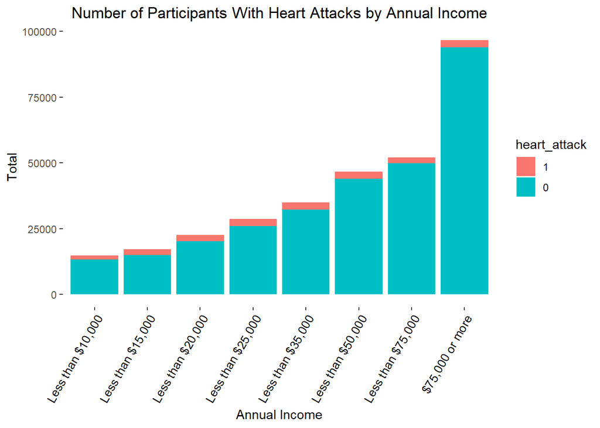

Look at the weight distribution of the participants.

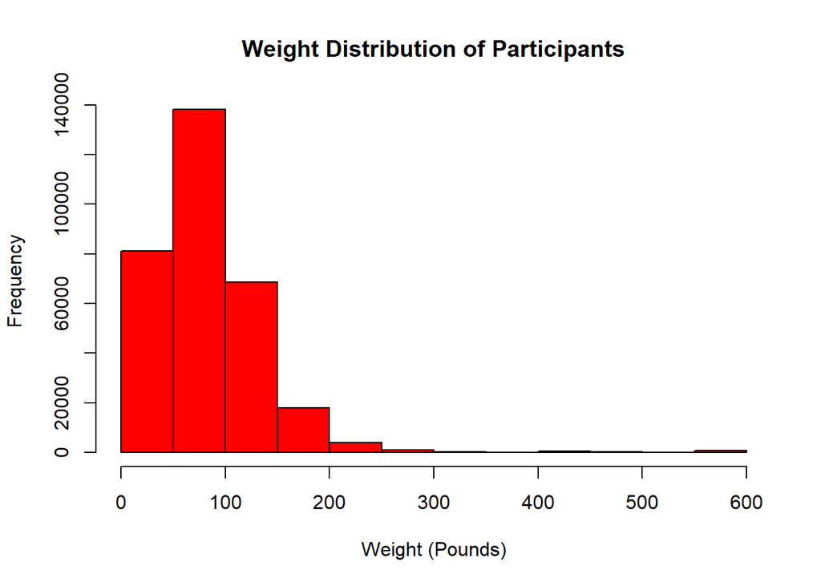

Look at the ratio of heart attacks depending on the participants’ gender.

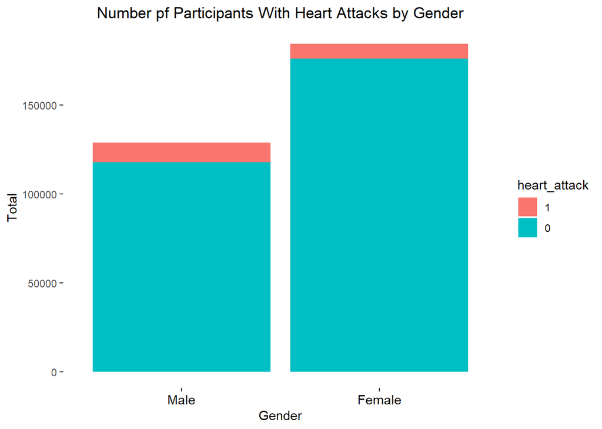

Now that we have carried out EDa analysis on the variables which we will use for the models, it is time to build different models.

## Hypothesis Tests

Before the models are built, some hypothesis testing will be carried out to see which variables are dependent or independent from the heart attacks.

### Chi-Squared Tests of Independence

Start off by carrying out chi-squared test of independence for the different categorical variables.

Chi-Squared Test for General Health And Heart Attack

Chi-Squared Test for Mental Health And Heart Attack

Chi-Squared Test for Health Coverage And Heart Attack

Chi-Squared Test for High Blood Pressure And Heart Attack

Chi-Squared Test for Time Since Last Cholesterol Check And Heart Attack

Chi-Squared Test for Told If Cholesterol Was High And Heart Attack

Chi-Squared Test for Angina And Heart Attack

Chi-Squared Test for Stroke And Heart Attack

Chi-Squared Test for Asthma And Heart Attack

Chi-Squared Test for Depression And Heart Attack

Chi-Squared Test for Kidney Disease And Heart Attack

Chi-Squared Test for Diabetes And Heart Attack

Chi-Squared Test for Veteran Status And Heart Attack

Chi-Squared Test for Marital Status And Heart Attack

Chi-Squared Test for Education Level And Heart Attack

Chi-Squared Test for Employment Status And Heart Attack

Chi-Squared Test for Annual Income And Heart Attack

Chi-Squared Test for Gender And Heart Attack

Chi-Squared Test for Difficulty Walking And Heart Attack

Chi-Squared Test for Smoked at Least 100 Cigarettes And Heart Attack

Chi-Squared Test for Use of Smokeless Tobacco Products And Heart Attack

Chi-Squared Test for Exercise in the Past 30 Days And Heart Attack

Chi-Squared Test for Age (5 Year Bucket) And Heart Attack

After all of the Chi-Squared Tests of Independence are carried out, create a table to summarise the P-values for each test and also whether to include them in our modelling or not.

Null Hypothesis: The two variables are independent.

Alternative Hypothesis: The two variables are dependent.

| Categorical Variable | Chi-Test P-value < 0.05? | Include? |
| --- | --- | --- |
| gen_health | TRUE | Yes |
| mental_health | TRUE | Yes |
| health_coverage | TRUE | Yes |
| high_bp | TRUE | Yes |
| time_since_cholcheck | TRUE | Yes |
| told_high_chol | TRUE | Yes |
| angina | TRUE | Yes |
| stroke | TRUE | Yes |
| ashtma | TRUE | Yes |
| depression | TRUE | Yes |
| kidney_disease | TRUE | Yes |
| diabetes | TRUE | Yes |
| veteran | TRUE | Yes |
| marital_status | TRUE | Yes |
| education_level | TRUE | Yes |
| employment_status | TRUE | Yes |
| income | TRUE | Yes |
| sex | TRUE | Yes |
| difficulty_walk | TRUE | Yes |
| smoke_100 | TRUE | Yes |
| smokeless_tabac | FALSE | No |
| exercise_30 | TRUE | Yes |
| age5yr_bucket | TRUE | Yes |

Based on the table above, we reject the null hypothesis for all variables except smokeless_tabac. At a 0.05 threshold, all categorical variables have a dependent relationship with heart_attack except smokeless_tabac. We will exclude smokeless_tabac in our models.

## Modeling

After carrying out the Chi-Squared Test of Indepence to determine which categorical variables to use in our models, its time to build the models. Start off by using classification trees.

### Getting Test and Training Sets

Before diving into the creation of our first classification tree, we noticed that the data is imbalanced. This is a common occurence when working with medical data. Only 6.1% of the participants had heart attacks in our cleaned up dataset. In order to balance our dataset for training and testing, we identified 19212 people with heart attacks and subset them. Then, we randomly samples 19212 other participants from the dataframe that contained no heart attacks. Finally, we put these two dataframes together to get a balanced dataset with a total of 38424 records.

```
## [1] 38424
```

```
##              state    month gen_health mental_health health_coverage sleep_time
## 38420     Virginia    March  Very good            30               1          5
## 38421      Florida December       Good             0               1          8
## 38422 North Dakota   August       Fair            20               1          5
## 38423      Florida February  Excellent             0               1          7
## 38424     Nebraska   August  Excellent             0               1          7
##       high_bp time_since_cholcheck told_high_chol heart_attack angina stroke
## 38420       1     Within past year             No            0      0      0
## 38421       0     Within past year             No            0      0      0
## 38422       1     Within past year            Yes            0      0      0
## 38423       0  5 or more years ago             No            0      0      0
## 38424       0     Within past year             No            0      0      0
##       asthma depression kidney_disease diabetes veteran marital_status
## 38420      0          0              0        0       1        Widowed
## 38421      0          0              0        0       0        Married
```

[output cut: 33 more lines]

Now that we have a balanced dataset, we split the data into training and test sets. We opted to use 30% of the data for testing and 70% for training.

### Decision Trees

```
##
## Classification tree:
## tree(formula = heart_attack ~ gen_health + mental_health + health_coverage +
##     sleep_time + high_bp + time_since_cholcheck + angina + stroke +
##     asthma + depression + kidney_disease + diabetes + veteran +
##     marital_status + education_level + employment_status + income +
##     weight + sex + difficulty_walk + smoke_100 + alc_past_30 +
##     fruit_freq + green_veg_freq + exercise_30 + age5yr_bucket,
##     data = bal_hrt_attack_training)
## Variables actually used in tree construction:
## [1] "angina"            "employment_status" "gen_health"
## [4] "high_bp"
## Number of terminal nodes:  5
## Residual mean deviance:  0.9275 = 24950 / 26900
## Misclassification error rate: 0.2266 = 6098 / 26908
```

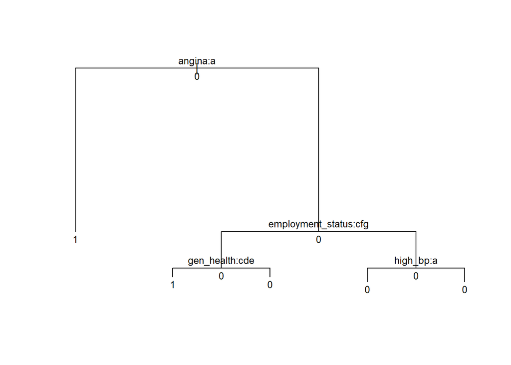

We can see that the variables in order of importance for determining heart attack are: angina, employment_status, gen_health, and high_bp. Many of the predictor variables are ignored as part of the tree function because their contributions to the model are very insignificant

After creating the above tree, we want to assess how it classifies our training cases. To do so, we will create a confusion matrix and assess metrics like accuracy, precision, and recall.

```
## [1] "Overall: "
```

```
##       Accuracy          Kappa  AccuracyLower  AccuracyUpper   AccuracyNull
##   7.733759e-01   5.467542e-01   7.683259e-01   7.783669e-01   5.000743e-01
## AccuracyPValue  McnemarPValue
##   0.000000e+00   1.624187e-09
```

```
## [1] "Class: "
```

```
##          Sensitivity          Specificity       Pos Pred Value
##            0.7908861            0.7558710            0.7640764
##       Neg Pred Value            Precision               Recall
##            0.7833487            0.7640764            0.7908861
##                   F1           Prevalence       Detection Rate
##            0.7772501            0.4999257            0.3953843
## Detection Prevalence    Balanced Accuracy
##            0.5174669            0.7733786
```

We now look at a confusion matrix to see how well the tree classifies our test cases. We also have calculated accuracy below. We can see that our first decision tree classified the test cases with 77.6% accuracy.

```
##
## tree.pred    1    0
##         1 4502 1322
##         0 1258 4434
```

```
## [1] 0.7759639
```

Next we will perform some cross validation to decide if our tree would benefit from any pruning.

```
## [1] 5 4 2 1
```

```
## [1]  6087  6087  6904 13691
```

Based on the cross validation, we can see that the optimal number of splits for the tree are either 5 or 4. Because of these results, we will keep our original tree with four splits, as pruning the tree would provide no benefit.

Next we attempt to perform bagging. This involves using all predictor variables to make a whole bunvh of trees. Using more than one tree will hopefully increase model performance.

[output not shown]

We can see that the performance of the bagged tree performed with slightly better accuracy.

```
##
## tree.pred_bagged    1    0
##                1 4465 1091
##                0 1295 4665
```

```
## [1] 0.79281
```

Next we will look at random forest and see if we can get even better accuracy.

```
##
## Call:
##  randomForest(formula = heart_attack ~ ., data = bal_hrt_attack_training,      mtry = 2, importance = TRUE)
##                Type of random forest: classification
##                      Number of trees: 500
## No. of variables tried at each split: 2
##
##         OOB estimate of  error rate: 19.18%
## Confusion matrix:
##       1     0 class.error
## 1 11027  2425   0.1802706
## 0  2735 10721   0.2032551
```

The confusion matrix and accuracy for the random forest is given below.

```
##
## tree.pred_randForest    1    0
##                    1 4671 1199
##                    0 1089 4557
```

```
## [1] 0.8013199
```

### Logistic Regression

Key variables identified in trees in order of significance: agina, employment status, gen health, high bp

```
##
## Call:
## glm(formula = heart_attack ~ angina + employment_status + gen_health +
##     high_bp, family = "binomial", data = bal_hrt_attack_training)
##
## Deviance Residuals:
##     Min       1Q   Median       3Q      Max
## -2.4129  -0.6417   0.2637   0.7430   2.8386
##
## Coefficients:
##                                 Estimate Std. Error z value Pr(>|z|)
## (Intercept)                     -0.98883    0.07761 -12.742  < 2e-16 ***
## angina0                          2.86465    0.05119  55.962  < 2e-16 ***
## employment_statusSelf-employed  -0.45763    0.06697  -6.833 8.30e-12 ***
## employment_statusUnemployed     -0.51834    0.07695  -6.736 1.63e-11 ***
## employment_statusA homemaker    -0.24288    0.07711  -3.150  0.00163 **
## employment_statusA student       0.71730    0.23391   3.067  0.00217 **
## employment_statusRetired        -1.08726    0.03909 -27.814  < 2e-16 ***
## employment_statusUnable to work -0.83801    0.06013 -13.936  < 2e-16 ***
## gen_healthVery good             -0.48681    0.06292  -7.737 1.02e-14 ***
## gen_healthGood                  -1.03022    0.06124 -16.822  < 2e-16 ***
## gen_healthFair                  -1.51037    0.06622 -22.809  < 2e-16 ***
## gen_healthPoor                  -1.93484    0.08049 -24.039  < 2e-16 ***
## high_bp0                         0.74870    0.03352  22.335  < 2e-16 ***
## ---
## Signif. codes:  0 '***' 0.001 '**' 0.01 '*' 0.05 '.' 0.1 ' ' 1
##
## (Dispersion parameter for binomial family taken to be 1)
##
##     Null deviance: 37302  on 26907  degrees of freedom
## Residual deviance: 24241  on 26895  degrees of freedom
## AIC: 24267
##
## Number of Fisher Scoring iterations: 5
```

Growth/decay factors for each explanatory variable (calculated as exponentials of the model coefficients):

```
##                     (Intercept)                         angina0
##                       0.3720124                      17.5429231
##  employment_statusSelf-employed     employment_statusUnemployed
##                       0.6327841                       0.5955090
##    employment_statusA homemaker      employment_statusA student
##                       0.7843630                       2.0488906
##        employment_statusRetired employment_statusUnable to work
##                       0.3371376                       0.4325725
##             gen_healthVery good                  gen_healthGood
##                       0.6145825                       0.3569283
##                  gen_healthFair                  gen_healthPoor
##                       0.2208282                       0.1444481
##                        high_bp0
##                       2.1142463
```

Confidence intervals of each coefficient of the model:

```
##                                      2.5 %      97.5 %
## (Intercept)                     -1.1409330 -0.83672337
## angina0                          2.7643210  2.96498028
## employment_statusSelf-employed  -0.5888868 -0.32636515
## employment_statusUnemployed     -0.6691557 -0.36752185
## employment_statusA homemaker    -0.3940169 -0.09174987
## employment_statusA student       0.2588417  1.17575519
## employment_statusRetired        -1.1638794 -1.01064905
## employment_statusUnable to work -0.9558662 -0.72014450
## gen_healthVery good             -0.6101274 -0.36349696
## gen_healthGood                  -1.1502562 -0.91018476
## gen_healthFair                  -1.6401535 -1.38058683
## gen_healthPoor                  -2.0925891 -1.77708150
## high_bp0                         0.6829969  0.81439990
```

Hosmer and Lemeshow Goodness of Fit:

```
##
##  Hosmer and Lemeshow goodness of fit (GOF) test
##
## data:  bal_hrt_attack_training$heart_attack, fitted(heart_attack_logit1)
## X-squared = 26908, df = 8, p-value < 2.2e-16
```

McFadden test:

```
##           llh       llhNull            G2      McFadden          r2ML
## -1.212060e+04 -1.865120e+04  1.306122e+04  3.501440e-01  3.845507e-01
##          r2CU
##  5.127343e-01
```

The McFadden value of this model is 0.350144, which means that about 35% of the variations in y is explained by the variables in the model.

ROC & AUC analysis:  
Use training and test datasets to evaluate the area under the curve (AUC) for each.

Training:

```
## Area under the curve: 0.8692
```

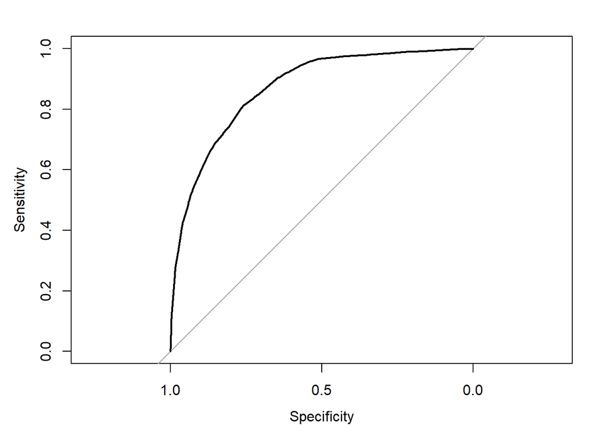

Test set:

```
## Area under the curve: 0.8661
```

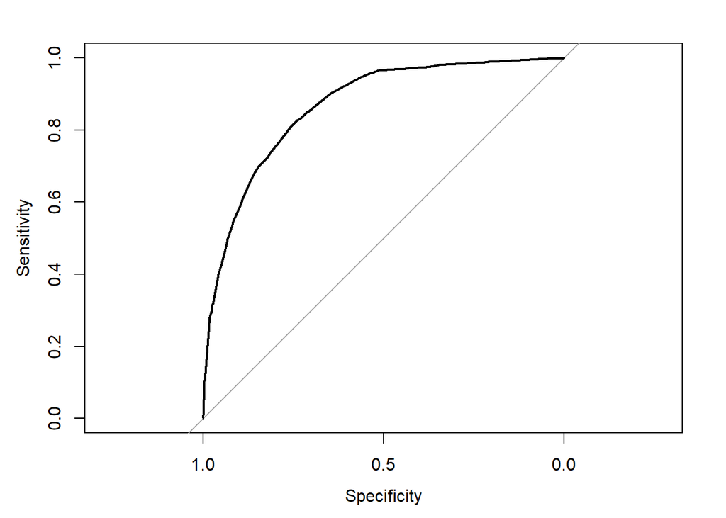

The the area-under-curve is 0.8661435 which is also above .8, meaning that this is a strong model.

Create confusion matrix from logistic regression output

```
##
##     FALSE TRUE
##   1  4187 1573
##   0   953 4803
```

## Comparisons Between Models

[output not shown]